# DataFest 2017 | Intro to dynamic web documents with dashboards and Shiny

18 January 2017

## Acknowledgements

Thanks so much to Garrett Grolemund and RStudio for providing us with helpful suggestions and examples, some of which we've included here.

## About you

Complete the survey: https://goo.gl/forms/b0UuRnpxpfjwpiD93

## Prerequisits

- Basic familiarity with R (e.g. can install packages, source files, and so on).
- Familiarity with R Markdown would be a benefit.
- Have a laptop with the following software installed:
  - R and RStudio
  - `rmarkdown`, `flexdashboard`, and `shiny` packages for R
- Working internet connection

## Dynamic and interactive documents

## Interactive documents

When your output documents are in **HTML**, you can create interactive visualisations.

Potentially–though not always–more engaging and could let users explore data on their own.

## Big distinction:

**Client Side**: HTML documenst are rendered on the user's (client's) computer. Often **JavaScript in the browser**. You simply send them static HTML/JavaScript needed for their browser to create the plots. Could be sent from a services such as [RPubs](https://rpubs.com/).

**Server Side**: Data manipulations and/or plots (e.g. with [shinyapps](https://www.shinyapps.io/)) are done on a **server in R**. Browsers don't come with R built in.

## R Markdown to HTML

## R Markdown Review

You can use R Markdown to create HTML documents.

See http://rmarkdown.rstudio.com/ for an introduction to R Markdown.

## Display code chunks refresh

Use three back-ticks (```) to **start** and **end** a code chunk that is **not run**.

To create a **knit-able** code chunk begin the chunk with ````{r}`. Close the chunk with another three ticks.

## Chunk options

Change how R Markdown chunks behave with **options**. Place options in the chunk head: ````{r echo=FALSE, error=FALSE}`

| Option | What it Does |
| --- | --- |
| `echo=FALSE` | Does not print the code only the output |
| `error=FALSE` | Does not print errors |
| `include=FALSE` | Does not include the code or output, but does run the code |
| `fig.width` | Sets figure width |
| `cache=TRUE` | Cache the chunk. It is only run when the contents change. |

Many others at http://yihui.name/knitr/options

## R Markdown header

The key is to declare `html_document` in the header. E.g.:

```
output:
    html_document
```

## Simple example:

For example, we can summarise the survey data using: http://tinyurl.com/jx4gty2.

Which downloads your survey data from Google Sheets and creates . . .

## Static HTML example results

[figure not shown]

## Do . . .

Copy the code at http://tinyurl.com/jx4gty2 used to create the survey summary document.

**Add an additional code chunk plotting** responses to the question "Have you ever built a 'data dashboard'?"

## htmlwidgets

## Web-native visualisations

There are a growing number of R packages that make it easy to create interactive/web native visualisations.

Many of these are based on a framework called **htmlwidgets**.

## Leaflet

```r
library(leaflet); library(dplyr)

leaflet() %>% addTiles() %>% fitBounds(0, 40, 10, 50)
```

[interactive chart not shown]

## networkD3

```r
library(networkD3); data(MisLinks); data(MisNodes)

forceNetwork(Links = MisLinks, Nodes = MisNodes, Source = "source",
             Target = "target", Value = "value", NodeID = "name",
             Group = "group", opacity = 0.7, zoom = TRUE)
```

[interactive chart not shown]

## dygraphs

```r
library(dygraphs)
dygraph(nhtemp, main = "New Haven Temperatures") %>%
    dyRangeSelector(dateWindow = c("1920-01-01", "1960-01-01"))
```

[interactive chart not shown]

## DT

```r
library(DT)
datatable(iris, options = list(pageLength = 5))
```

|  | Sepal.Length | Sepal.Width | Petal.Length | Petal.Width | Species |
| --- | --- | --- | --- | --- | --- |
| 1 | 5.1 | 3.5 | 1.4 | 0.2 | setosa |
| 2 | 4.9 | 3 | 1.4 | 0.2 | setosa |
| 3 | 4.7 | 3.2 | 1.3 | 0.2 | setosa |
| 4 | 4.6 | 3.1 | 1.5 | 0.2 | setosa |
| 5 | 5 | 3.6 | 1.4 | 0.2 | setosa |
| 6 | 5.4 | 3.9 | 1.7 | 0.4 | setosa |
| 7 | 4.6 | 3.4 | 1.4 | 0.3 | setosa |
| 8 | 5 | 3.4 | 1.5 | 0.2 | setosa |
| 9 | 4.4 | 2.9 | 1.4 | 0.2 | setosa |
| 10 | 4.9 | 3.1 | 1.5 | 0.1 | setosa |

[output cut: 140 more lines]

## Static dashboards

## What is a dashboard?

Dashboards provide an **overview** of key data.

The [flexdashboard](http://rmarkdown.rstudio.com/flexdashboard/) R package allows you to easily create dashboards with [R Markdown](http://rmarkdown.rstudio.com/).

## For example . . .

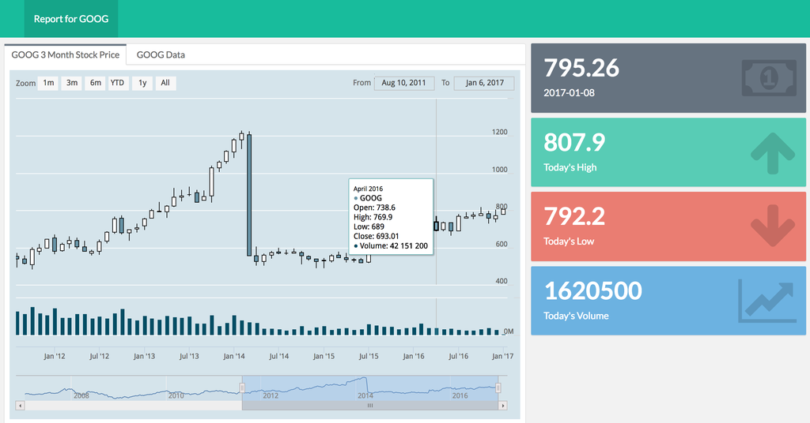

## For example . . .

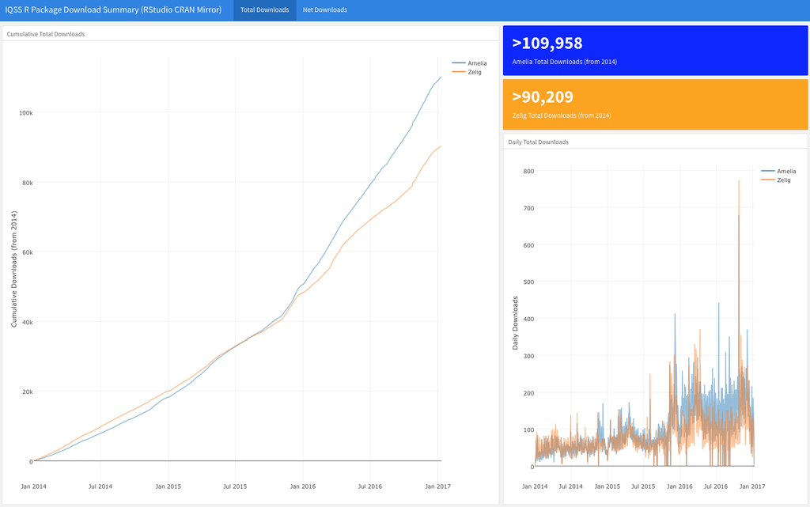

## Getting started

Once you have the flexdashboard package installed, in RStudio select `File` > `New File` > `R Markdown...`. Then, select `Flex Dashboard` from the `From Template` new R Markdown type:

[figure not shown]

## Basic flexdashboard syntax: Header

Like other R Markdown documents, flexdashboards start with a [YAML](http://yaml.org/) header. E.g.:

[output not shown]

## Basic flexdashboard syntax: Rows

Dashboard rows are delimited by the 3rd level markdown header: `###`.

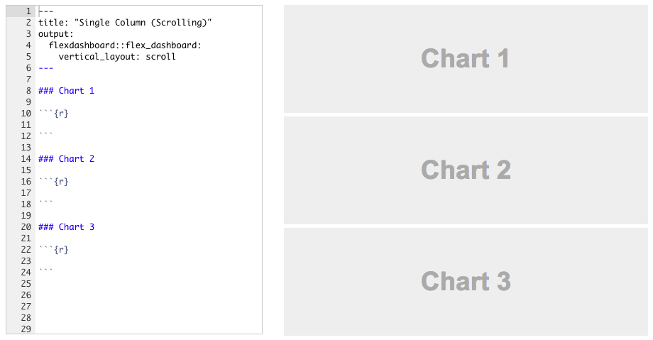

Source: http://rmarkdown.rstudio.com/flexdashboard/

## Basic flexdashboard syntax: Columns

Separate columns are delimited with `Column` followed by `-------------------`. Column widths can be set in the section heading with the `data-width` attribute.

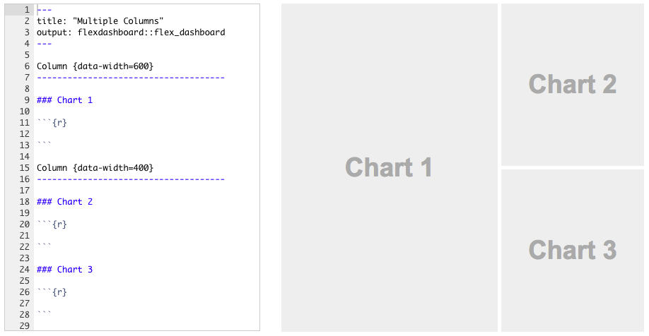

Source: http://rmarkdown.rstudio.com/flexdashboard/

## Tabbed pages

You can create multi-page dashboards by placing the table label followed by, on a new line, `======================`. E.g.

```
Net Downloads
===========================================
```

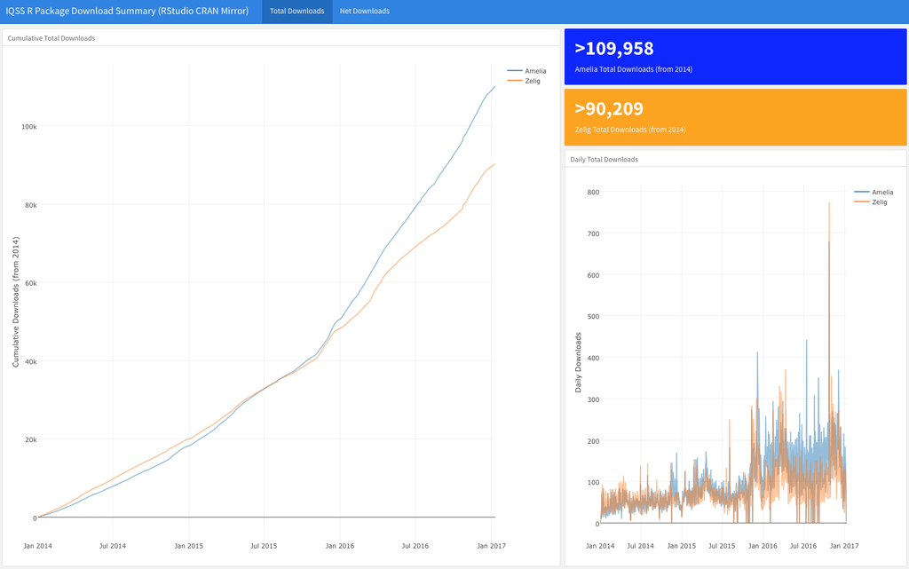

## Tabsets

Adding `.tabset` to a section heading can create tabs within a specific section.

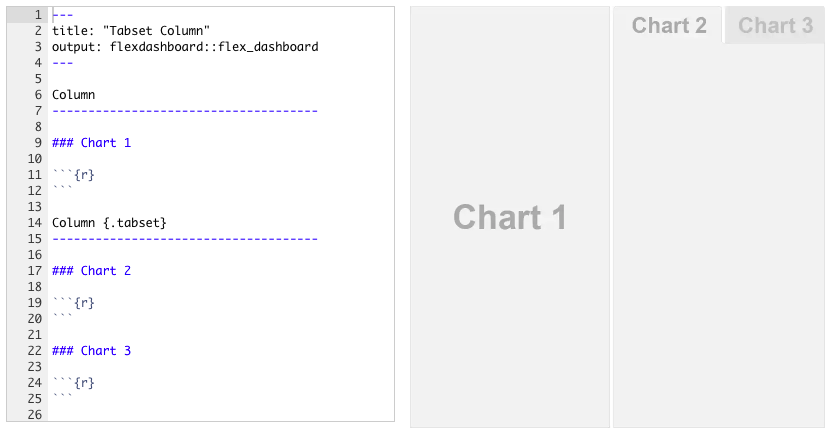

## Do . . .

We could make a dashboard from the hometowns you provided.

Here's an example (using fake data): http://tinyurl.com/hgk3fxx

**You:** make a similar dashboard using R source code available at: http://tinyurl.com/zwszswb

Hint: it's typically good practice to place **setup code** in a separate chunk just under the header, with the code chunk option `include=FALSE`.

## Full code

Full code for the exercise can be found: http://tinyurl.com/zwk5het.

## Hosting documents created on the client-side

## Hosting client-side rendered HTML

There are lots of **free** services (e.g. RPubs, GitHub Pages) for hosting webpages for client side plot rendering.

## Hosting through RPubs

1. Create an [RPubs](https://rpubs.com/) account.
2. After **knitting** an R Markdown document to HTML, click on *Publish* > *Publish Document…* in the output viewer.
3. In the resulting pop-up box, click *RPubs* > *Publish*

[figure not shown]

## RPubs dashboard example

For example: http://rpubs.com/christophergandrud/datafest_ex_dashboard.

Note: RPubs documents do not update when new data is available. It is a static file host.

## Dynamic + Interactive Dashboards

## Shiny flexdashboards

1. Add `runtime: shiny` to the YAML header options to declare the dashboard a shiny flexdashboard.
2. Add a `{.sidebar}` attribute to the first column in the dashboard. This is where we will place the controls.
3. Add Shiny [inputs](http://shiny.rstudio.com/tutorial/lesson3/) and [outputs](http://shiny.rstudio.com/tutorial/lesson4/).

## Shiny dashboard example

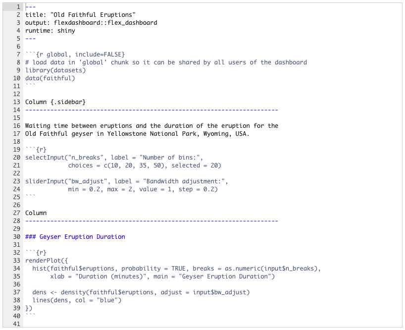

Source: http://rmarkdown.rstudio.com/flexdashboard/shiny.html

## Result

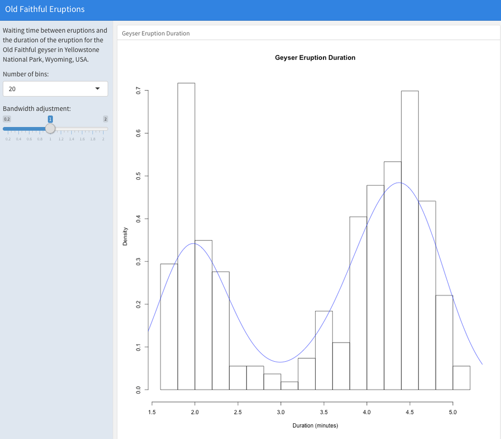

## Syntax breakdown: Inputs

```r
selectInput("n_breaks", label = "Number of bins:",
            choices = c(10, 20, 35, 50), selected = 20)

sliderInput("bw_adjust", label = "Bandwidth adjustment:",
            min = 0.2, max = 2, value = 1, step = 0.2)
```

Creates **two elements in** a new `input` object: `n_breaks` and `bw_adjust`.

## Syntax breakdown: Outputs

`input` is passed to the output code in `renderPlot`:

```r
renderPlot({
    hist(faithful$eruptions, probability = TRUE,
         breaks = as.numeric(input$n_breaks),
         xlab = "Duration (minutes)",
         main = "Geyser Eruption Duration")

    dens <- density(faithful$eruptions, adjust = input$bw_adjust)
    lines(dens, col = "blue")
})
```

## Do . . .

Create a new shiny dashboard that **subsets** our Google Sheets survey data based on participants **position** (e.g. "undergraduate", "faculty") and returns a bar plot of the subset's **R skill level**.

R code available at: http://tinyurl.com/hwp5pgf

## Result

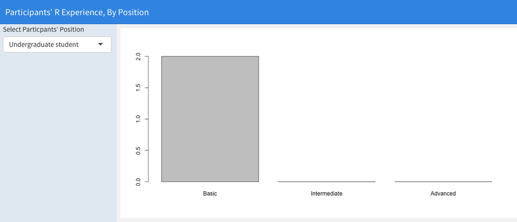

## Serving Shiny Documents

## Hosting through shinyapps.io

1. Create a [shinyapps.io](http://www.shinyapps.io/) account and follow sign up instructions.
2. After **running** your shiny app, click on *Publish* > *Publish Document…* in the output viewer.
3. In the resulting pop-up box connect your ShinyApps.io account following the onscreen instructions and **publishe**.

[figure not shown]